# Informe HDT8

Fredy Velasquez Pablo Escobar Angel Higueros

2023-04-30

# HDT 8: Redes Neuronales Artificiales (RNA)

```r
#Librerias necesarias
library(caret)
library(nnet)
library(neural)
library(dummy)
library(neuralnet)


#Conjunto de datos a utilizar
data<-read.csv('train.csv')



#Quitar nulos
data[is.na(data)] <- 0
#Calculo de percentiles
percentil <- quantile(data$SalePrice)
#Percentiles
estado<-c('Estado')
data$Estado<-estado
#Economica=0
#Intermedia=1
#Cara=2
data <- within(data, Estado[SalePrice<=129975] <- 'Economica')
data$Estado[(data$SalePrice>129975 & data$SalePrice<=163000)] <- 'Intermedia'
data$Estado[data$SalePrice>163000] <- 'Cara'


#Cambio de tipo de columnas

data$SalePrice<-as.numeric(data$SalePrice)
data$GrLivArea<-as.numeric(data$GrLivArea)
data$GarageCars<-as.numeric(data$GarageCars)
data$YearBuilt<-as.numeric(data$YearBuilt)
data$GarageArea<-as.numeric(data$GarageArea)
data$X1stFlrSF<-as.numeric(data$X1stFlrSF)

data$Estado<-as.factor(data$Estado)

porcentaje<-0.7
set.seed(123)
datos<-data.frame(data$SalePrice,data$GrLivArea,data$GarageCars,data$YearBuilt,data$GarageArea,data$X1stFlrSF,data$Estado)

corte <- sample(nrow(datos),nrow(datos)*porcentaje)
train<-datos[corte,]
test<-datos[-corte,]

#-------------------------------------------------
# Red Neuronal con nnet
#-------------------------------------------------

modelo.nn2 <- nnet(data.Estado~.,data = datos,subset = corte, size=2, rang=0.1,
                   decay=5e-4, maxit=200)
prediccion2 <- as.data.frame(predict(modelo.nn2, newdata = test[,1:6]))
columnaMasAlta<-apply(prediccion2, 1, function(x) colnames(prediccion2)[which.max(x)])
test$prediccion2<-columnaMasAlta #Se le añade al grupo de prueba el valor de la predicción

modelo1<-confusionMatrix(as.factor(test$prediccion2),test$data.Estado)


#-------------------------------------------------
# Red Neuronal con caret
#-------------------------------------------------

modeloCaret <- train(data.Estado~., data=train, method="nnet", trace=F)
test$prediccionCaret<-predict(modeloCaret, newdata = test[,1:6])
modelo2<-confusionMatrix(test$prediccionCaret,test$data.Estado)
```

### Modelos de clasificación usando redes neuronales.

#### Usando nnet

```r
modelo1
```

```
## Confusion Matrix and Statistics
##
##             Reference
## Prediction   Cara Economica Intermedia
##   Cara        225       109        105
##   Economica     0         0          0
##   Intermedia    0         0          0
##
## Overall Statistics
##
##                Accuracy : 0.5125
##                  95% CI : (0.4647, 0.5602)
##     No Information Rate : 0.5125
##     P-Value [Acc > NIR] : 0.5192
##
##                   Kappa : 0
##
##  Mcnemar's Test P-Value : NA
##
## Statistics by Class:
##
##                      Class: Cara Class: Economica Class: Intermedia
## Sensitivity               1.0000           0.0000            0.0000
## Specificity               0.0000           1.0000            1.0000
## Pos Pred Value            0.5125              NaN               NaN
## Neg Pred Value               NaN           0.7517            0.7608
## Prevalence                0.5125           0.2483            0.2392
## Detection Rate            0.5125           0.0000            0.0000
## Detection Prevalence      1.0000           0.0000            0.0000
## Balanced Accuracy         0.5000           0.5000            0.5000
```

#### Usando caret

```r
modelo2
```

```
## Confusion Matrix and Statistics
##
##             Reference
## Prediction   Cara Economica Intermedia
##   Cara        223         0          5
##   Economica     2       109         99
##   Intermedia    0         0          1
##
## Overall Statistics
##
##                Accuracy : 0.7585
##                  95% CI : (0.7157, 0.7979)
##     No Information Rate : 0.5125
##     P-Value [Acc > NIR] : < 2.2e-16
##
##                   Kappa : 0.6071
##
##  Mcnemar's Test P-Value : < 2.2e-16
##
## Statistics by Class:
##
##                      Class: Cara Class: Economica Class: Intermedia
## Sensitivity               0.9911           1.0000          0.009524
## Specificity               0.9766           0.6939          1.000000
## Pos Pred Value            0.9781           0.5190          1.000000
## Neg Pred Value            0.9905           1.0000          0.762557
## Prevalence                0.5125           0.2483          0.239180
## Detection Rate            0.5080           0.2483          0.002278
## Detection Prevalence      0.5194           0.4784          0.002278
## Balanced Accuracy         0.9839           0.8470          0.504762
```

Ahora con el segundo modelo percibimos mejores resultados, obteniendo una precisión de 0.7585 y por ende, las equivocaciones de este modelo fueron menos, siendo 106 casas mal clasificadas.

Entonces, el segundo modelo fue mejor en cuanto a efectividad y menor número de equivocaciones. Y respecto al tiempo de procesamiento, ambos tomaron tiempos similares al ejecutarse.

### SalePrice como variable de respuesta.

```r
#Librerias necesarias
library(nnet)
library(neuralnet)
library(ggplot2)


#Conjunto de datos a utilizar
data<-read.csv('train.csv')


#Cambio de tipo de columnas

data$SalePrice<-as.numeric(data$SalePrice)
data$GrLivArea<-as.numeric(data$GrLivArea)
data$GarageCars<-as.numeric(data$GarageCars)
data$YearBuilt<-as.numeric(data$YearBuilt)
data$GarageArea<-as.numeric(data$GarageArea)
data$X1stFlrSF<-as.numeric(data$X1stFlrSF)
#Funcion para normalizar los datos
normalize <- function(x) {
  return ((x - min(x)) / (max(x) - min(x)))
}



porcentaje<-0.7
set.seed(123)
#Creamos el dataframe para predecir
datos2<-data.frame(data$GrLivArea,data$GarageCars,data$YearBuilt,data$GarageArea,data$X1stFlrSF,data$SalePrice)
#Creamos el dataframe con los datos normalizados
datos <- as.data.frame(lapply(datos2, normalize))


corte <- sample(nrow(datos),nrow(datos)*porcentaje)
train<-datos[corte,]
test<-datos[-corte,]

#-------------------------------------------------
# Red Neuronal con nnet
#-------------------------------------------------
#Prediccion
modelo.nn2 <- nnet(as.numeric(data.SalePrice)~.,data = datos,subset = corte, size=2, rang=0.1,decay=5e-4, maxit=200)
prediccion1 <- predict(modelo.nn2, newdata = test,na.rm=TRUE)

#Desnormalizar datos
minvec <- sapply(datos2,min)
maxvec <- sapply(datos2,max)
denormalize <- function(x,minval,maxval) {
  x*(maxval-minval) + minval
}
#Desnormalizamos el dataframe
datos<-as.data.frame(Map(denormalize,datos,minvec,maxvec))
#Desnormalizamos la prediccion
prediccion1_r<-(prediccion1)*(max(datos2)-min(datos2))+min(datos2)
```

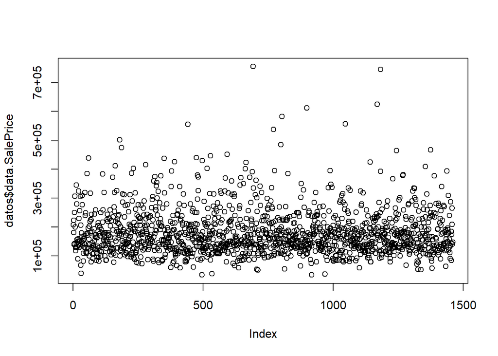

```r
plot(datos$data.SalePrice)
```

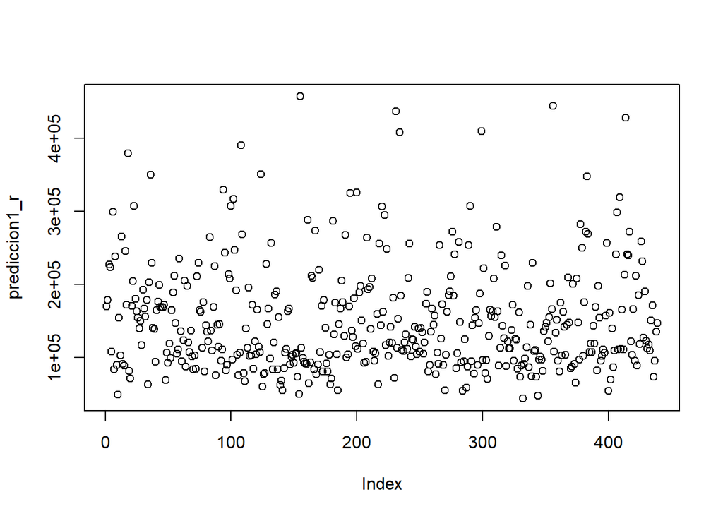

```r
plot(prediccion1_r)
```

### Compare la eficiencia del mejor modelo de RNA con los resultados obtenidos con los algoritmos de las hojas de trabajo anteriores. ¿Cuál es mejor para predecir? ¿Cuál se demoró más en procesar?

Nuestro modelo numero #2, fue nuestro mejor modelo, obtuvo un valor de 0.75%, realmente comparado con las hojas de trabajo anteriores no es el mejor modelo, porque es un valor bajo, pero realmente cumple con su funcion, hace de una manera correcta la prediccion, pero el cual puede mejorar posiblemente cambiando las variables categoricas o incluso agregando mas variables. Pero a nivel de demora, realmente todos se toman el mismo tiempo, tiempo que solo varia en cuestion de milisegundos o incluso en el mayor de los casos, un segundo.

### Compare los resultados del mejor modelo de esta hoja para clasificar con los resultados de los algoritmos usados para clasificar de las hojas de trabajo anteriores

En esta hoja, el mejor resultado que logramos fue con el modelo #2, el que realizamos con la libreria de Caret, obtuvimos un acierto del 0.75%, comparado con las hojas de trabajo anteriores, la verdad es que esta un poco bajo, mas sin embargo no esta fuera de la media que hemos tenido, podemos mencionar la hoja de trabajo con Arboles de decision, en la cual obtuvimos un valor de 0.70, lo cual es bastante semejante, pero comparado con las otra hojas sigue siendo bajo.

### Ahora que ha usado todos los modelos que hemos visto y aplicados al conjunto de datos llegue a conclusiones sobre cual es o cuales son los mejores modelos para clasificar dadas las características del conjunto de datos. ¿Cuál o cuáles son los mejores para predecir el precio de las casas?

Realmente, luego de haber trabajado con todos los modelos, y tomando en cuanta los resultados anteriores, podemos concluir que el mejor modelo, o por lo menos el modelo que mejor nos resulto a nosotros, fue el modelo de Naive Bayes, en ese modelo llegamos a tener un nivel de acierto del 0.93%, lo cual podemos decir que es casi excelente, el otro modelo que nos ha resultado muy eficiente fue el de Random Forest, con el cual llegamos a tener un nivel de acierto de 0.82%.

Con base en lo anterior, podemos entoncer concluir con que los mejores modelos para precedir el precio de las casas con las condiciones dadas por el conjunto de datos, son:

1. NAIVE BAYES.
2. RANDOM FOREST.